# Ciência dos Dados - PROJETO 2

## 1. Problema

O Classificador Naive-Bayes, o qual se baseia no uso do teorema de Bayes, é largamente utilizado em filtros anti-spam de e-mails. O classificador permite calcular qual a probabilidade de uma mensagem ser SPAM considerando as palavras em seu conteúdo e, de forma complementar, permite calcular a probabilidade de uma mensagem ser HAM dada as palavras descritas na mensagem.

Para realizar o MVP (minimum viable product) do projeto, você precisa programar uma versão do classificador que "aprende" o que é uma mensagem SPAM considerando uma base de treinamento e comparar o desempenho dos resultados com uma base de testes.

## 2. Separação da base de dados em Treinamento e Teste

A base de dados deve ser separada em duas partes, aleatoriamente, considerando:

[output not shown]

```python
import pandas as pd
from scipy import stats
import matplotlib.pyplot as plt
import os.path
import numpy as np
import math
from random import shuffle
```

```python
emails = pd.read_excel("spamham2019.xlsx") #lê o excel
remover = [',','@','/',':',';','r$','\n','\(','\)','#','\?','-','"','\[','\]']

for i in remover:
    emails.Email = emails.Email.replace(i,'',regex=True)
```

```python
dicio = emails.to_dict('records')
shuffle(dicio)
df2 = pd.DataFrame.from_dict(dicio)
df3 = df2.head(int(len(df2)*0.75))
df4 = df2.tail(int(len(df2)*0.05))
```

## 3. Classificador Naive-Bayes

```python
spam = df3.Class

prob = spam.value_counts()

prob_ham = prob[0]/len(spam)

prob_spam = prob[1]/len(spam)

print("Probabilidade de ser relevante:",int(prob_ham * 100),'%')
print('Probabilidade de ser irrelevante',int(prob_spam * 100),'%')
```

```
Probabilidade de ser relevante: 86 %
Probabilidade de ser irrelevante 13 %
```

```python
presunto = df3[df3.Class == 'ham'] #Separa os presuntos relevantes
relevantes = np.sum(presunto.Email).split()
quant_em_relev =  pd.Series(relevantes)
todos_relevantes = len(relevantes)
quant_em_relev.value_counts().head(3)
```

```
to     1132
you    1124
I       815
dtype: int64
```

```python
queijo = df3[df3.Class == 'spam'] #Separa os queijos relevantes
irelevantes = np.sum(queijo.Email).split()
quant_em_irelev =  pd.Series(irelevantes)
todos_irelevantes = len(irelevantes)
quant_em_irelev.value_counts().head(3)
```

```
to    450
a     274
or    137
dtype: int64
```

```python
todas_as_palavras = irelevantes + relevantes



def P_spam_palavra(palavra):
    if palavra in irelevantes:
        return ((1 + quant_em_irelev.value_counts()[palavra])/(len(todas_as_palavras) + len(irelevantes)))
    else:
        return 1/(len(todas_as_palavras) + len(irelevantes))

def P_palavra_spam(palavra):
    x = (P_spam_palavra(palavra) * P_palavra(palavra)) / prob_spam
    return x

def P_palavra(palavra):
    quant_pal = (quant_em_irelev.value_counts()[palavra] + quant_em_relev.value_counts()[palavra])
    quant_tot = len(irelevantes)+len(relevantes)
    return (quant_pal/quant_tot)

def P_ham_palavra(palavra):
    if palavra in relevantes:
        return ((1 + quant_em_relev.value_counts()[palavra])/(len(todas_as_palavras) + len(relevantes)))
    else:
        return 1/(len(todas_as_palavras) + len(irelevantes))

def P_palavra_ham(palavra):
    x = (P_ham_palavra(palavra) * P_palavra(palavra)) / prob_ham
    return x

def P_spam_mensagem(mensagem):
    palavras = mensagem.split(' ')
    prob = 0
    contador = 0
    for palavra in palavras:
        if palavra in todas_as_palavras:
            if contador == 0:
                prob += P_spam_palavra(palavra)
            else:
                prob *= P_spam_palavra(palavra)
        else:
            pass
    return prob

def P_ham_mensagem(mensagem):
    palavras = mensagem.split(' ')
    prob = 0
    contador = 0
    for palavra in palavras:
        if palavra in todas_as_palavras:
            if contador == 0:
                prob += P_ham_palavra(palavra)
            else:
                prob *= P_ham_palavra(palavra)
        else:
            pass
    return prob

def Hamlet(mensagem):
    ham = P_ham_mensagem(mensagem)
    spam = P_spam_mensagem(mensagem)
    if ham > spam:
        return 'ham'
    else:
        return 'spam'
#test = []

#for i in df3.Email:
#    test.append(Hamlet(i))
#df3['NB'] = test
```

```python
test1 = []
for e in df4.Email:
    test1.append(Hamlet(e))
df4['NB'] = test1
```

```python
df5 = df4.reset_index(drop=True)
```

```python
falso_neg = 0
falso_pos = 0
pos_ver = 0
neg_ver = 0
Spam = 0
Ham = 0

for e in range(len(df5)):
    if df5.Class[e] == 'spam':
        Spam += 1
        if df5.NB[e] == 'spam':
            pos_ver += 1

        elif df5.NB[e] != 'spam':
            falso_neg += 1

    elif df5.Class[e] == 'ham':
        Ham += 1
        if df5.NB[e] == 'ham' :
            neg_ver += 1

        elif df5.NB[e] != 'ham':
            falso_pos += 1

total = falso_neg + falso_pos + pos_ver + neg_ver

p1= float(falso_pos/Ham * 100)
p2= float(pos_ver/Spam * 100)
p3= float(falso_neg/Spam * 100)
p4= float(neg_ver/Ham * 100)


print('Porcentagem de positivos verdadeiros: {0:.2f}%'.format(p2))

print('Porcentagem de negativos verdadeiros: {0:.2f}%'.format(p4))
```

```
Porcentagem de positivos verdadeiros: 13.20%
Porcentagem de negativos verdadeiros: 98.83%
```

O teste estava demorando em torno de vinte minutos para rodar, por isso seria inviável rodá-lo 10.000 vezes. Portanto, decidimos rodar 10 vezes e fazer um bootstrap para aumentar o número de observações.

## 4. Qualidade do Classificador alterando a base de treinamento

```python
resultados = []

for o in range(10):
    dicio = emails.to_dict('records')
    shuffle(dicio)
    df6 = pd.DataFrame.from_dict(dicio)
    df7 = df6.head(int(len(df2)*0.75))
    df8 = df7.tail(int(len(df2)*0.25))
    df9 = df8.reset_index(drop=True)

    test2 = []
    for e in range(len(df9.Email)):
        test2.append(Hamlet(df9.Email[e]))
    df9['NB'] = test2

    posi_ver = 0
    nega_ver = 0
    Spam1 = 0
    Ham1 = 0

    for e in range(len(df9)):
        if df9.Class[e] == 'spam':
            Spam += 1
            if df9.NB[e] == 'spam':
                pos_ver += 1

            elif df9.NB[e] != 'spam':
                falso_neg += 1

        elif df9.Class[e] == 'ham':
            Ham += 1
            if df9.NB[e] == 'ham' :
                neg_ver += 1

            elif df9.NB[e] != 'ham':
                falso_pos += 1

    total = falso_neg + falso_pos + pos_ver + neg_ver

    positivo_ver= float(pos_ver/Spam * 100)
    negativo_ver= float(neg_ver/Ham * 100)
    results = [positivo_ver, negativo_ver]

    resultados.append(results)
```

```
[]
```

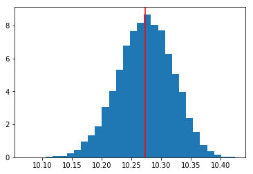

```python
results_pv = []
results_nv = []

for e in range(len(resultados)):
    results_pv.append(resultados[e][0])
    results_nv.append(resultados[e][1])


n_vezes = 10000

size = len(results_pv)

medias_pv = []
medias_nv = []

for i in range(n_vezes):
    results_pv_fake = np.random.choice(results_pv, size = size, replace=True)
    results_nv_fake = np.random.choice(results_nv, size = size, replace=True)
    media_pv = np.mean(results_pv_fake)
    media_nv = np.mean(results_nv_fake)
    medias_pv.append(media_pv)
    medias_nv.append(media_nv)



plt.hist(medias_pv, density=True, bins=30);
plt.axvline(np.mean(results_pv), color="r")
plt.plot()
```

```
[]
```

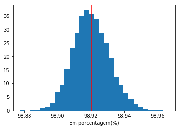

```python
plt.hist(medias_nv, density=True, bins=30);
plt.axvline(np.mean(results_nv), color="r")
plt.xlabel('Em porcentagem(%)')
plt.plot()
```

```python
df_pv = pd.DataFrame(medias_pv)
df_nv = pd.DataFrame(medias_nv)
```

```python
df_pv.describe()
```

|  | 0 |
| --- | --- |
| count | 10000.000000 |
| mean | 10.273340 |
| std | 0.045660 |
| min | 10.071097 |
| 25% | 10.242915 |
| 50% | 10.274304 |
| 75% | 10.305528 |
| max | 10.424255 |

```python
df_nv.describe()
```

|  | 0 |
| --- | --- |
| count | 10000.000000 |
| mean | 98.920132 |
| std | 0.010914 |
| min | 98.877694 |
| 25% | 98.912688 |
| 50% | 98.919669 |
| 75% | 98.927342 |
| max | 98.965978 |

Depois de feito o bootstrap foi possível plotar os histogramas e observar suas semelhanças com uma normal. A Média dos positivos verdadeiros é de 10,273340% e dos negativos verdadeiros é de 98,920132%.